# Cyclistic Data Analysis

Emmanuel Pascua

2022-07-09

```r
# Install required packages
#install.packages("tidyverse")
#install.packages("lubridate")
# Load packages
library(tidyverse)
library(lubridate)
#Set working directory
getwd()
```

```
## [1] "D:/FILES/DATA ANALYTICS/PORTFOLIO/CYCLISTIC/DATA"
```

```r
setwd("D:/FILES/DATA ANALYTICS/PORTFOLIO/CYCLISTIC/DATA")
```

## Cyclistic Bike Service Case Study

About the company

In 2016, Cyclistic launched a successful bike-share offering. Since then, the program has grown to a fleet of 5,824 bicycles that are geotracked and locked into a network of 692 stations across Chicago. The bikes can be unlocked from one station and returned to any other station in the system anytime.

Until now, Cyclistic’s marketing strategy relied on building general awareness and appealing to broad consumer segments. One approach that helped make these things possible was the flexibility of its pricing plans: single-ride passes, full-day passes, and annual memberships. Customers who purchase single-ride or full-day passes are referred to as casual riders. Customers who purchase annual memberships are Cyclistic members.

Cyclistic’s finance analysts have concluded that annual members are much more profitable than casual riders. Although the pricing flexibility helps Cyclistic attract more customers, Moreno believes that maximizing the number of annual members will be key to future growth. Rather than creating a marketing campaign that targets all-new customers, Moreno believes there is a very good chance to convert casual riders into members. She notes that casual riders are already aware of the Cyclistic program and have chosen Cyclistic for their mobility needs.

Moreno has set a clear goal: Design marketing strategies aimed at converting casual riders into annual members. In order to do that, however, the marketing analyst team needs to better understand how annual members and casual riders differ, why casual riders would buy a membership, and how digital media could affect their marketing tactics. Moreno and her team are interested in analyzing the Cyclistic historical bike trip data to identify trends.

#### Additional Information

Although Cyclistic is a fictional company, it is based on a real company with a real dataset and for that reason, I took the liberty to check on their policies and pricing.

For members, only the first 45 minutes of each ride are included in the membership price. For casual users, Cyclistic allows unlimited number of 3 hour rides over a 24-hour period.

#### Scope of Work

Stage

Deliverable

Problem Definition

- Formulate a clear statement of the business task
- Identify metrics that we can use in accomplishing the business task

Data Preprocessing

- Verify data integrity and completeness
- Clean and organize data
- What variables are available for analysis

Data Transformation

- Check data for errors
- Transform data to work with it effectively

Data Analysis

- Aggregate data to compare customer segments
- Perform calculations
- Visualize data to provide easy-to-understand insights
- Identify trends

Presentation

- Make a presentation slide to share with stakeholders
- Create a dashboard

Recommendation

- Conclude the study with recommendations

## Problem Definition

Three questions will guide the future marketing program:

1. How do annual members and casual riders use Cyclistic bikes differently?
2. Why would casual riders buy Cyclistic annual memberships?
3. How can Cyclistic use digital media to influence casual riders to become members?

To start with defining the problem, we can load the data into this document.

```r
#Import Data
m1_2021 <- read_csv("202101-divvy-tripdata.csv", show_col_types = FALSE)
m2_2021 <- read_csv("202102-divvy-tripdata.csv", show_col_types = FALSE)
m3_2021 <- read_csv("202103-divvy-tripdata.csv", show_col_types = FALSE)
m4_2021 <- read_csv("202104-divvy-tripdata.csv", show_col_types = FALSE)
m5_2021 <- read_csv("202105-divvy-tripdata.csv", show_col_types = FALSE)
m6_2021 <- read_csv("202106-divvy-tripdata.csv", show_col_types = FALSE)
m7_2021 <- read_csv("202107-divvy-tripdata.csv", show_col_types = FALSE)
m8_2021 <- read_csv("202108-divvy-tripdata.csv", show_col_types = FALSE)
m9_2021 <- read_csv("202109-divvy-tripdata.csv", show_col_types = FALSE)
m10_2021 <- read_csv("202110-divvy-tripdata.csv", show_col_types = FALSE)
m11_2021 <- read_csv("202111-divvy-tripdata.csv", show_col_types = FALSE)
m12_2021 <- read_csv("202112-divvy-tripdata.csv", show_col_types = FALSE)

#Check column names consistency
colnames(m1_2021)
```

```
##  [1] "ride_id"            "rideable_type"      "started_at"
##  [4] "ended_at"           "start_station_name" "start_station_id"
##  [7] "end_station_name"   "end_station_id"     "start_lat"
## [10] "start_lng"          "end_lat"            "end_lng"
## [13] "member_casual"
```

```r
colnames(m2_2021)
```

```
##  [1] "ride_id"            "rideable_type"      "started_at"
##  [4] "ended_at"           "start_station_name" "start_station_id"
##  [7] "end_station_name"   "end_station_id"     "start_lat"
## [10] "start_lng"          "end_lat"            "end_lng"
## [13] "member_casual"
```

```r
colnames(m3_2021)
```

```
##  [1] "ride_id"            "rideable_type"      "started_at"
##  [4] "ended_at"           "start_station_name" "start_station_id"
##  [7] "end_station_name"   "end_station_id"     "start_lat"
## [10] "start_lng"          "end_lat"            "end_lng"
## [13] "member_casual"
```

```r
colnames(m4_2021)
```

```
##  [1] "ride_id"            "rideable_type"      "started_at"
##  [4] "ended_at"           "start_station_name" "start_station_id"
##  [7] "end_station_name"   "end_station_id"     "start_lat"
## [10] "start_lng"          "end_lat"            "end_lng"
## [13] "member_casual"
```

```r
colnames(m5_2021)
```

```
##  [1] "ride_id"            "rideable_type"      "started_at"
##  [4] "ended_at"           "start_station_name" "start_station_id"
##  [7] "end_station_name"   "end_station_id"     "start_lat"
## [10] "start_lng"          "end_lat"            "end_lng"
## [13] "member_casual"
```

```r
colnames(m6_2021)
```

```
##  [1] "ride_id"            "rideable_type"      "started_at"
##  [4] "ended_at"           "start_station_name" "start_station_id"
##  [7] "end_station_name"   "end_station_id"     "start_lat"
## [10] "start_lng"          "end_lat"            "end_lng"
## [13] "member_casual"
```

```r
colnames(m7_2021)
```

```
##  [1] "ride_id"            "rideable_type"      "started_at"
##  [4] "ended_at"           "start_station_name" "start_station_id"
##  [7] "end_station_name"   "end_station_id"     "start_lat"
## [10] "start_lng"          "end_lat"            "end_lng"
## [13] "member_casual"
```

```r
colnames(m8_2021)
```

```
##  [1] "ride_id"            "rideable_type"      "started_at"
##  [4] "ended_at"           "start_station_name" "start_station_id"
##  [7] "end_station_name"   "end_station_id"     "start_lat"
## [10] "start_lng"          "end_lat"            "end_lng"
## [13] "member_casual"
```

```r
colnames(m9_2021)
```

```
##  [1] "ride_id"            "rideable_type"      "started_at"
##  [4] "ended_at"           "start_station_name" "start_station_id"
##  [7] "end_station_name"   "end_station_id"     "start_lat"
## [10] "start_lng"          "end_lat"            "end_lng"
## [13] "member_casual"
```

```r
colnames(m10_2021)
```

```
##  [1] "ride_id"            "rideable_type"      "started_at"
##  [4] "ended_at"           "start_station_name" "start_station_id"
##  [7] "end_station_name"   "end_station_id"     "start_lat"
## [10] "start_lng"          "end_lat"            "end_lng"
## [13] "member_casual"
```

```r
colnames(m11_2021)
```

```
##  [1] "ride_id"            "rideable_type"      "started_at"
##  [4] "ended_at"           "start_station_name" "start_station_id"
##  [7] "end_station_name"   "end_station_id"     "start_lat"
## [10] "start_lng"          "end_lat"            "end_lng"
## [13] "member_casual"
```

```r
colnames(m12_2021)
```

```
##  [1] "ride_id"            "rideable_type"      "started_at"
##  [4] "ended_at"           "start_station_name" "start_station_id"
##  [7] "end_station_name"   "end_station_id"     "start_lat"
## [10] "start_lng"          "end_lat"            "end_lng"
## [13] "member_casual"
```

```r
#Join data
cyc2021 <- bind_rows(m1_2021,m2_2021,m3_2021,m4_2021,m5_2021,m6_2021,m7_2021,m8_2021,m9_2021,m10_2021,m11_2021,m12_2021)

#Drop these immediately to save memory
rm(m1_2021)
rm(m2_2021)
rm(m3_2021)
rm(m4_2021)
rm(m5_2021)
rm(m6_2021)
rm(m7_2021)
rm(m8_2021)
rm(m9_2021)
rm(m10_2021)
rm(m11_2021)
rm(m12_2021)

head(cyc2021)
```

```
## # A tibble: 6 × 13
##   ride_id rideable_type started_at          ended_at            start_station_n…
##   <chr>   <chr>         <dttm>              <dttm>              <chr>
## 1 E19E6F… electric_bike 2021-01-23 16:14:19 2021-01-23 16:24:44 California Ave …
## 2 DC88F2… electric_bike 2021-01-27 18:43:08 2021-01-27 18:47:12 California Ave …
## 3 EC45C9… electric_bike 2021-01-21 22:35:54 2021-01-21 22:37:14 California Ave …
## 4 4FA453… electric_bike 2021-01-07 13:31:13 2021-01-07 13:42:55 California Ave …
## 5 BE5E8E… electric_bike 2021-01-23 02:24:02 2021-01-23 02:24:45 California Ave …
## 6 5D8969… electric_bike 2021-01-09 14:24:07 2021-01-09 15:17:54 California Ave …
## # … with 8 more variables: start_station_id <chr>, end_station_name <chr>,
## #   end_station_id <chr>, start_lat <dbl>, start_lng <dbl>, end_lat <dbl>,
## #   end_lng <dbl>, member_casual <chr>
```

With this, we can aggregate our data by time, day, month, types of bike available to compare the difference of usage behavior between two customer segments.

Although each data point indicates whether the user is a member or not, it does not include any information about the customer. It will be helpful if there could be something to identify each individual user such as a unique user ID even for casual users such that we can understand user behavior beyond looking the by-trip data.

We need to identify areas and times where and when casual users tend to use the service. With that information, we can customize our digital marketing efforts such that those areas and those times can be incorporated in the campaign. Cyclistic could partner up with social media influencers in promoting the service.

## Data Pre-processing

We can check for missing values by running the code below

```r
na_count <-sapply(cyc2021, function(y) sum(length(which(is.na(y))))) %>%
  data.frame() %>%
  mutate(percent_missing = (./(nrow(cyc2021)) * 100)) %>%
  select(c(2))
head(na_count)
```

```
##                    percent_missing
## ride_id                    0.00000
## rideable_type              0.00000
## started_at                 0.00000
## ended_at                   0.00000
## start_station_name        12.34676
## start_station_id          12.34671
```

```r
tail(na_count)
```

```
##                percent_missing
## end_station_id      13.2111113
## start_lat            0.0000000
## start_lng            0.0000000
## end_lat              0.0852716
## end_lng              0.0852716
## member_casual        0.0000000
```

## Data Transformation

We can begin transforming our data so we can work with it effectively during analysis. We begin by converting the contents of the “started_at” column and storing them in new columns. We can also extract the “hour” so we can use it later.

```r
#make new columns from existing columns
cyc2021$date <- as.Date(cyc2021$started_at)
cyc2021$month <- format(cyc2021$date, "%m")
cyc2021$day <- format(cyc2021$date, "%d")
cyc2021$year <- format(cyc2021$date, "%Y")
cyc2021$day_of_week <- format(cyc2021$date, "%A")

cyc2021$start_time <- format(cyc2021$started_at, "%H:%M")
cyc2021$start_hour <- format(cyc2021$started_at, "%H")
head(cyc2021)
```

```
## # A tibble: 6 × 20
##   ride_id rideable_type started_at          ended_at            start_station_n…
##   <chr>   <chr>         <dttm>              <dttm>              <chr>
## 1 E19E6F… electric_bike 2021-01-23 16:14:19 2021-01-23 16:24:44 California Ave …
## 2 DC88F2… electric_bike 2021-01-27 18:43:08 2021-01-27 18:47:12 California Ave …
## 3 EC45C9… electric_bike 2021-01-21 22:35:54 2021-01-21 22:37:14 California Ave …
## 4 4FA453… electric_bike 2021-01-07 13:31:13 2021-01-07 13:42:55 California Ave …
## 5 BE5E8E… electric_bike 2021-01-23 02:24:02 2021-01-23 02:24:45 California Ave …
## 6 5D8969… electric_bike 2021-01-09 14:24:07 2021-01-09 15:17:54 California Ave …
## # … with 15 more variables: start_station_id <chr>, end_station_name <chr>,
## #   end_station_id <chr>, start_lat <dbl>, start_lng <dbl>, end_lat <dbl>,
## #   end_lng <dbl>, member_casual <chr>, date <date>, month <chr>, day <chr>,
## #   year <chr>, day_of_week <chr>, start_time <chr>, start_hour <chr>
```

For this next transformation step, I created a new column that shows the total ride length per trip.

We can also check the values by the summary function.

```r
cyc2021$ride_length <- (as.numeric(difftime(cyc2021$ended_at, cyc2021$started_at, unit="secs")) / 60)
is.numeric(cyc2021$ride_length)
```

```
## [1] TRUE
```

```r
#quickly check the ride_length
summary(cyc2021$ride_length)
```

```
##     Min.  1st Qu.   Median     Mean  3rd Qu.     Max.
##   -58.03     6.75    12.00    21.94    21.78 55944.15
```

There appears to be a negative value in our ride length. According to the project guide, there are data entries representing the times when bikes were taken to HQ for maintenance so we need to drop those data to ensure integrity.

```r
cyc2021 <- cyc2021[!(cyc2021$ride_length < 0 | cyc2021$start_station_name == "HQ QR"),] # drop rows by the condition
cyc2021 <- cyc2021[rowSums(is.na(cyc2021)) != ncol(cyc2021), ] # drop missing rows
```

#### Bike-use overtime

The max ride length indicates 55944.150 minutes. This is equivalent 38.85 days. In this case, the user would have been fined a certain amount

According to Divvy’s policy, a member has 45 minutes of free rides included in the membership price and day pass holders (“casual”) are allowed to have unlimited number of 3 hour rides over a 24-hour period without incurring additional charges so I would like to have a subset of the data where trips exceeded the allowed time. I want access to this data so we can check if we can find trends on the places and times where the time limits are exceeded.

```r
# Create dataframe for members where ride exceeded 45 minutes
cyc2021_ex_mem <- cyc2021[(cyc2021$ride_length > 45 & cyc2021$member_casual == "member"),]
cyc2021_ex_mem$ex_minutes <- as.double(cyc2021_ex_mem$ride_length) -  45
cyc2021_ex_mem <- cyc2021_ex_mem[rowSums(is.na(cyc2021_ex_mem)) != ncol(cyc2021_ex_mem), ]

# Create dataframe for casual users where ride exceeded 3 hours
cyc2021_ex_cas <- cyc2021[(cyc2021$ride_length > 180 & cyc2021$member_casual == "casual"),]
cyc2021_ex_cas$ex_minutes <- as.double(cyc2021_ex_cas$ride_length) -  180
cyc2021_ex_cas<- cyc2021_ex_cas[rowSums(is.na(cyc2021_ex_cas)) != ncol(cyc2021_ex_cas), ]

cyc2021_ex <- bind_rows(cyc2021_ex_cas, cyc2021_ex_mem)# Join
head(cyc2021_ex)
```

```
## # A tibble: 6 × 22
##   ride_id rideable_type started_at          ended_at            start_station_n…
##   <chr>   <chr>         <dttm>              <dttm>              <chr>
## 1 EC5171… classic_bike  2021-01-26 08:39:08 2021-01-26 12:35:58 Ritchie Ct & Ba…
## 2 6FAD41… docked_bike   2021-01-15 15:20:09 2021-01-16 08:09:42 Buckingham Foun…
## 3 E944A7… docked_bike   2021-01-12 10:59:02 2021-01-12 14:06:53 Indiana Ave & R…
## 4 C832F2… classic_bike  2021-01-07 00:31:02 2021-01-08 01:30:47 Vernon Ave & 79…
## 5 785FE7… classic_bike  2021-01-16 18:17:00 2021-01-17 08:15:11 California Ave …
## 6 0348F9… classic_bike  2021-01-24 00:46:04 2021-01-25 01:45:59 Ashland Ave & 7…
## # … with 17 more variables: start_station_id <chr>, end_station_name <chr>,
## #   end_station_id <chr>, start_lat <dbl>, start_lng <dbl>, end_lat <dbl>,
## #   end_lng <dbl>, member_casual <chr>, date <date>, month <chr>, day <chr>,
## #   year <chr>, day_of_week <chr>, start_time <chr>, start_hour <chr>,
## #   ride_length <dbl>, ex_minutes <dbl>
```

#### Ride Length Casual vs Member

In the previous steps, we created a new column to compute the length of trips. Let’s quickly look at the values with additional aggregation by user type.

```r
aggregate(cyc2021$ride_length ~ cyc2021$member_casual, FUN = mean)
```

```
##   cyc2021$member_casual cyc2021$ride_length
## 1                casual            33.89440
## 2                member            13.71228
```

```r
aggregate(cyc2021$ride_length ~ cyc2021$member_casual, FUN = median)
```

```
##   cyc2021$member_casual cyc2021$ride_length
## 1                casual           16.483333
## 2                member            9.716667
```

```r
aggregate(cyc2021$ride_length ~ cyc2021$member_casual, FUN = min)
```

```
##   cyc2021$member_casual cyc2021$ride_length
## 1                casual                   0
## 2                member                   0
```

```r
aggregate(cyc2021$ride_length ~ cyc2021$member_casual, FUN = max)
```

```
##   cyc2021$member_casual cyc2021$ride_length
## 1                casual           55944.150
## 2                member            1559.933
```

Let us add another variable to our aggregation.

```r
aggregate(cyc2021$ride_length ~ cyc2021$member_casual + cyc2021$day_of_week, FUN = mean)
```

```
##    cyc2021$member_casual cyc2021$day_of_week cyc2021$ride_length
## 1                 casual              Friday            32.28542
## 2                 member              Friday            13.36607
## 3                 casual              Monday            33.82513
## 4                 member              Monday            13.33530
## 5                 casual            Saturday            36.45691
## 6                 member            Saturday            15.40372
## 7                 casual              Sunday            39.53072
## 8                 member              Sunday            15.80742
## 9                 casual            Thursday            29.38985
## 10                member            Thursday            12.84006
## 11                casual             Tuesday            29.66655
## 12                member             Tuesday            12.84267
## 13                casual           Wednesday            29.36041
## 14                member           Wednesday            12.86251
```

The code returned a table showing aggregated data showing the days of the week but we can see that it follows no logical order. Let’s fix it by setting the levels of the “day of week” column by running the code below.

```r
cyc2021$day_of_week <- ordered(cyc2021$day_of_week, levels=c("Sunday", "Monday", "Tuesday", "Wednesday", "Thursday", "Friday", "Saturday"))
cyc2021_ex$day_of_week <- ordered(cyc2021_ex$day_of_week, levels=c("Sunday", "Monday", "Tuesday", "Wednesday", "Thursday", "Friday", "Saturday"))
```

## Analyze

In this phase of the case study, we will use ggplot2 to create quick visualizations to check trends in our data.

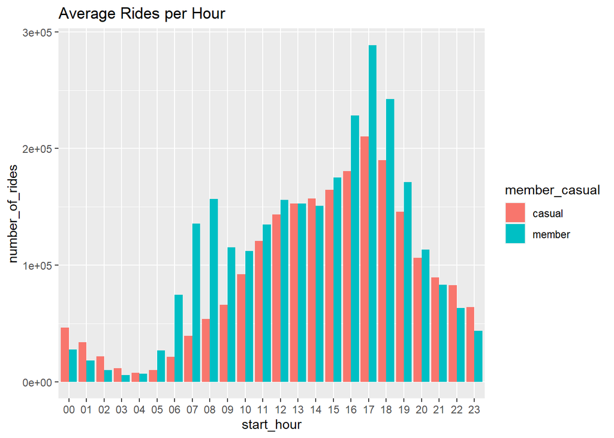

```r
#Number of rides per hour
cyc2021 %>%
  group_by(member_casual, start_hour) %>%  #groups by usertype and time of use
  summarise(number_of_rides = n(),average_duration = mean(ride_length)) %>%
  arrange(member_casual, start_hour) %>%
  ggplot(aes(x=start_hour, y=number_of_rides, fill=member_casual)) + geom_col(position="dodge") + labs(title = "Average Rides per Hour")
```

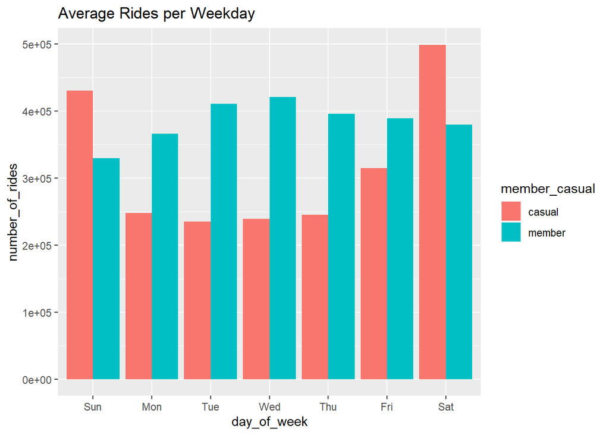

```r
#Number of rides per weekday
cyc2021 %>%
  mutate(day_of_week = wday(started_at, label = TRUE)) %>%  #creates weekday field using wday()
  group_by(member_casual, day_of_week ) %>%  #groups by usertype and weekday
  summarise(number_of_rides = n(),average_duration = mean(ride_length)) %>%
  arrange(member_casual, day_of_week) %>%
  ggplot(aes(x=day_of_week, y=number_of_rides, fill=member_casual)) + geom_col(position="dodge") + labs(title = "Average Rides per Weekday")
```

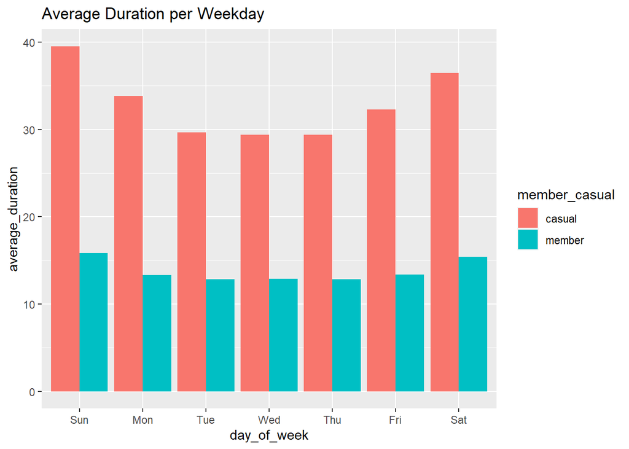

```r
# The graph shows that more members tend to use the service more during the middle of the week which is the reverse opposite of the
# casual users behavior.


#Average ride length per weekday
cyc2021 %>%
  mutate(day_of_week = wday(started_at, label = TRUE)) %>%  #creates weekday field using wday()
  group_by(member_casual, day_of_week ) %>%  #groups by usertype and weekday
  summarise(number_of_rides = n(),average_duration = mean(ride_length)) %>%
  arrange(member_casual, day_of_week) %>%
  ggplot(aes(x=day_of_week, y=average_duration, fill=member_casual)) + geom_col(position="dodge") + labs(title = "Average Duration per Weekday")
```

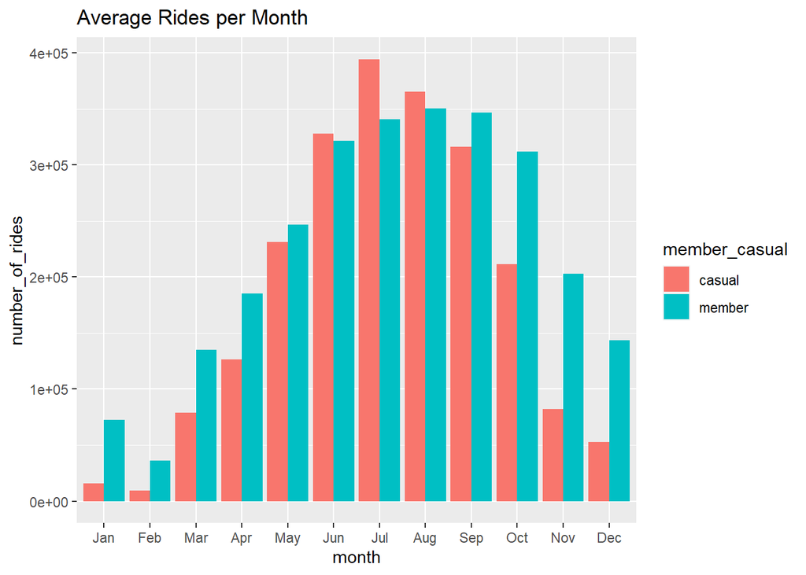

```r
#The graph shows that members maintain a fairly consistent ride_length throughout the week whil casual users tend to use the
# service more on the weekends

#Average number of rides per month
cyc2021 %>%
  mutate(month = month(started_at, label = TRUE)) %>%  #creates weekday field using month()
  group_by(member_casual, month) %>%  #groups by usertype and month
  summarise(number_of_rides = n(),average_duration = mean(ride_length)) %>%
  arrange(member_casual, month) %>%
  ggplot(aes(x=month, y=number_of_rides, fill=member_casual)) + geom_col(position="dodge") + labs(title = "Average Rides per Month")
```

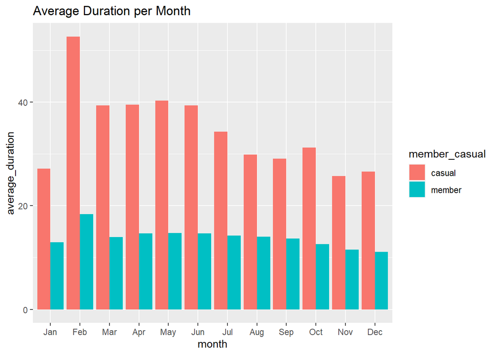

```r
#The graph suggests that the number of rides increase significantly towards the middle of the year with July as its peak.

#Average ride length per month
cyc2021 %>%
  mutate(month = month(started_at, label = TRUE)) %>%  #creates weekday field using month()
  group_by(member_casual, month) %>%  #groups by usertype and month
  summarise(number_of_rides = n(),average_duration = mean(ride_length)) %>%
  arrange(member_casual, month) %>%
  ggplot(aes(x=month, y=average_duration, fill=member_casual)) + geom_col(position="dodge") + labs(title = "Average Duration per Month")
```

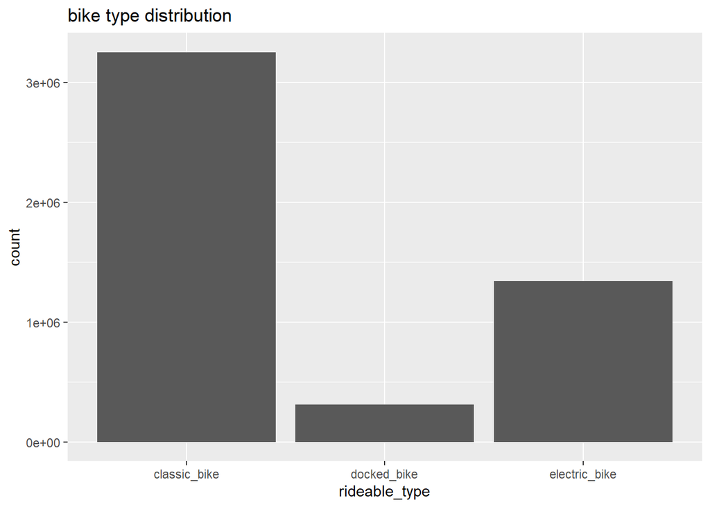

```r
#Distribution of rideable bike types
ggplot(cyc2021, mapping = aes(x = rideable_type)) + geom_bar() + labs(title = "bike type distribution")
```

Member’s bike usage peaks during rush hours that may indicate using it to commute for work and school

The graph shows that more members tend to use the service more during the middle of the week which is the reverse opposite of the casual users behavior.

**Average ride length per weekday**

The graph shows that members maintain a fairly consistent ride length throughout the week while casual users tend to use the service more on the weekends.

The graph suggests that the number of rides increase significantly towards the middle of the year with July as its peak.

**Average ride length per month**

**Geo-location**

The data has geo-locations on the start and end stations. This will be useful in mapping out popular areas where casual and members use the service.

## Presentation

A presentation slide with all the gained insights with data visualizations from this analysis will be available for reading on the same folder of my github repo. To access the dashboard for this analysis, please click the link below.

Tableau Link: https://public.tableau.com/app/profile/emmanuel.czar.pascua/viz/CyclisticCaseStudy_16574346505240/Dashboard1

## Recommendations

**Recommendations:**

1. To convert casual users to annual members, The company can incentivize continuous patronage for day pass holders to acquire a membership for a discounted cost upon accumulating certain points.
2. The company can also provide a scheme which takes advantage of their behavior to use the service more on the weekends to launch weekend challenges where users are encouraged to bike through certain locations to earn points for a free membership trial that may last for only a couple of months to get through the first hurdle of converting casual users to members.

   This free membership can be designed so that the company can retain these customers. It can be accomplished by offering lower renewal fees. This will ultimately need to be reviewed by financial analysts of the company.
3. Using the geo-location available, we can map-out locations and use that data to incorporate on our social media campaigns. The company can also partner up with local fitness advocates on social media platforms to introduce the above mentioned weekly challenges to more people.